# 2.TS.DataCombine

## Tidy Data Merging (recommended approach).

Hadley Wickham–who wrote the dplyr, ggvis,ggplot2,reshape,reshape2,tidyr,lubridate packages– advocates for a specific [framework](http://vita.had.co.nz/papers/tidy-data.pdf) for tidying data for easier data manipulation and analysis. The main points of tidy data are as follows: 1. Each variable forms a column - data value,site,etc… 2. Each observation forms a row - timestamp 3. Each type of observational unit forms a table - Either whole time series or separated by data type (turbidity, level)

We can tidy our data using this approach and make data manipulation a bit easier.

```r
# In order to tidy our data, the code will start out as more verbose, but end up being a lot easier. First let's subset each dataset to include only the data we are interested in.
tri.lvl <- tri.lvl[,c('DateTime','True_WL')]
tri.lvl$site <- 'Triassic'
slt.lvl <- slt.lvl[,c('DateTime','True_WL')]
slt.lvl$site <- 'Slate'
tri.turb <- tri.turb[,c('DateTime','Turb','Gain')]
tri.turb$site <- 'Triassic'
slt.turb <- slt.turb[,c('DateTime','Turb','Gain')]
slt.turb$site <- 'Slate'

head(tri.turb)
```

```
##         DateTime Turb Gain     site
## 1 1/8/2016 11:50  212   10 Triassic
## 2 1/8/2016 11:55  128   10 Triassic
## 3 1/8/2016 12:00  136   10 Triassic
## 4 1/8/2016 12:05  128   10 Triassic
## 5 1/8/2016 12:10  128   10 Triassic
## 6 1/8/2016 12:15  136   10 Triassic
```

```r
head(slt.turb)
```

```
##         DateTime Turb Gain  site
## 1 1/9/2016 12:10   58   10 Slate
## 2 1/9/2016 12:15   57   10 Slate
## 3 1/9/2016 12:20   55   10 Slate
## 4 1/9/2016 12:25   55   10 Slate
## 5 1/9/2016 12:30   56   10 Slate
## 6 1/9/2016 12:35   56   10 Slate
```

```r
#Now we have a bunch of data frames that have a very similar structure and we can already have two separate tidy dataframes by simply row binding each t.
l <- rbind(tri.lvl,slt.lvl)
t <- rbind(slt.turb,tri.turb)

#As of now the turbidity dataset is reported in terms of voltage. Using a calibration curve from another dataset we can convert this into Normalized Turbidity Unites (NTU). The calibration depends on the column labeld (gain)
t$TurbNTU <- NA

t[which(t$Gain == 10),'TurbNTU'] <- t[which(t$Gain == 10),'Turb']*0.0731 - 2.4933
t[which(t$Gain == 1),'TurbNTU'] <- t[which(t$Gain == 1),'Turb']*0.2755 - 150.504

#This NTU column is really all we want for the tidy data frame. So let's get rid of it and the Gain column
head(t)
```

```
##         DateTime Turb Gain  site TurbNTU
## 1 1/9/2016 12:10   58   10 Slate  1.7465
## 2 1/9/2016 12:15   57   10 Slate  1.6734
## 3 1/9/2016 12:20   55   10 Slate  1.5272
## 4 1/9/2016 12:25   55   10 Slate  1.5272
## 5 1/9/2016 12:30   56   10 Slate  1.6003
## 6 1/9/2016 12:35   56   10 Slate  1.6003
```

```r
t <- t[,c('DateTime','TurbNTU','site')]

#But can we combine all of these into one very tidy, very large t? Yes!
#But first we need to make sure each dataset has a column that tells us the datatype. And has identical column names.
names(l) <- c('DateTime','value','site')
names(t) <- c('DateTime','value','site')

l$data.type <- 'level.m'
t$data.type <- 'turb.ntu'

#Now the data frames have matched structures and can be rbound into a very 'long' dataset
long.dat <- rbind(l,t)

#This long data frame now allows us to add our 'min5' column easily
long.dat$min5 <- round_minute(mdy_hm(long.dat$DateTime,tz=mytz),5)

#Before we get the final dataset, the turbidity data is best from after Jan 9 at 9:30 AM, so let's subset our data.
good.turb <- mdy_hm('1/9/2016 9:30',tz=mytz)
long.dat <- long.dat[which(long.dat$min5 > good.turb),]

#And using the cast function from the reshape 2 package we can reshape this long dataframe into a wide data frame that will have each column showing our data of interest.
library(reshape2)
wide.dat <- dcast(long.dat,site+min5~data.type,value.var='value')
wider.dat <- dcast(long.dat,min5~data.type+site,value.var='value')
head(wide.dat)
```

```
##    site                min5   level.m turb.ntu
## 1 Slate 2016-01-09 09:35:00 0.1208726       NA
## 2 Slate 2016-01-09 09:40:00 0.1206726       NA
## 3 Slate 2016-01-09 09:45:00 0.1203836       NA
## 4 Slate 2016-01-09 09:50:00 0.1204990       NA
## 5 Slate 2016-01-09 09:55:00 0.1206056       NA
## 6 Slate 2016-01-09 10:00:00 0.1205254       NA
```

```r
head(wider.dat)
```

```
##                  min5 level.m_Slate level.m_Triassic turb.ntu_Slate
## 1 2016-01-09 09:35:00     0.1208726        0.1848988             NA
## 2 2016-01-09 09:40:00     0.1206726        0.1843966             NA
## 3 2016-01-09 09:45:00     0.1203836        0.1849120             NA
## 4 2016-01-09 09:50:00     0.1204990        0.1847274             NA
## 5 2016-01-09 09:55:00     0.1206056        0.1839428             NA
## 6 2016-01-09 10:00:00     0.1205254        0.1839868             NA
##   turb.ntu_Triassic
## 1            9.6413
## 2            9.6413
## 3            9.6413
## 4            9.0565
## 5            9.0565
## 6            9.0565
```

## Data Visualization

We have a final dataset called wide.dat. And we want to look at trends between turbidity in NTU and water level between the different sights. We can do this easily with dygraphs and ggplot2. I’m not going into much of an explanation of how ggplot works, but the internet is pretty good at [explaining](http://docs.ggplot2.org/current/) Let’s try it out here:

```r
#First let's just look at the level and turb data for each site.
lvl.xts <- xts(cbind(slate=wider.dat$level.m_Slate,triassic=wider.dat$level.m_Triassic),order.by=wider.dat$min5)
dygraph(lvl.xts,group='alldat') %>% dyOptions(useDataTimezone=T)
```

[interactive chart not shown]

```r
turb.xts <- xts(cbind(slate=wider.dat$turb.ntu_Slate,triassic=wider.dat$turb.ntu_Triassic),order.by=wider.dat$min5)
dygraph(turb.xts,group='alldat') %>% dyOptions(useDataTimezone=T)
```

[interactive chart not shown]

Now what about correlation between water level and turbidity for the whole TimeSeries?

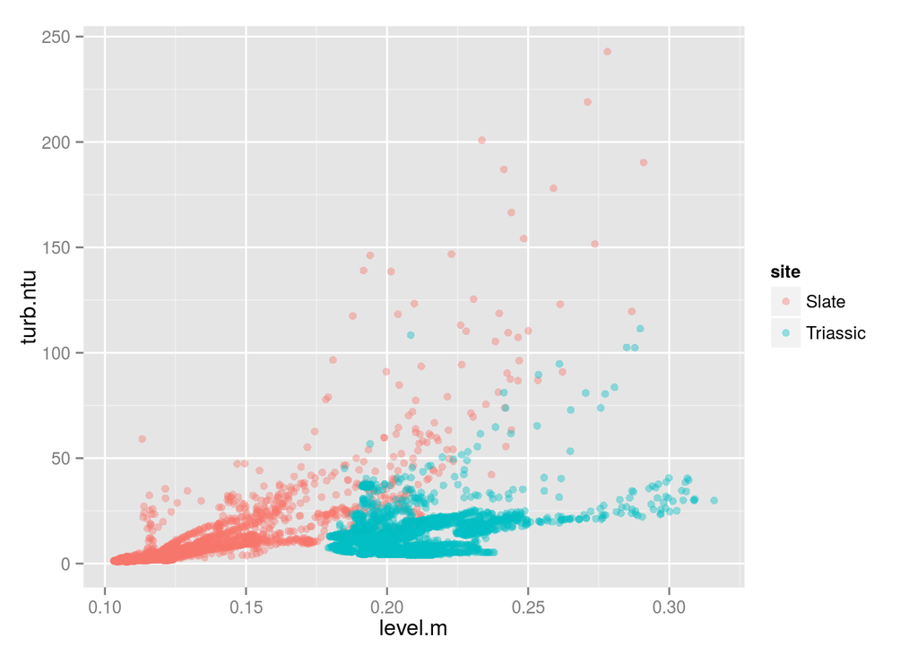

```r
library(ggplot2)
full.g <- ggplot(wide.dat, aes(level.m,turb.ntu,color=site))
full.g + geom_point(alpha=.4)
```

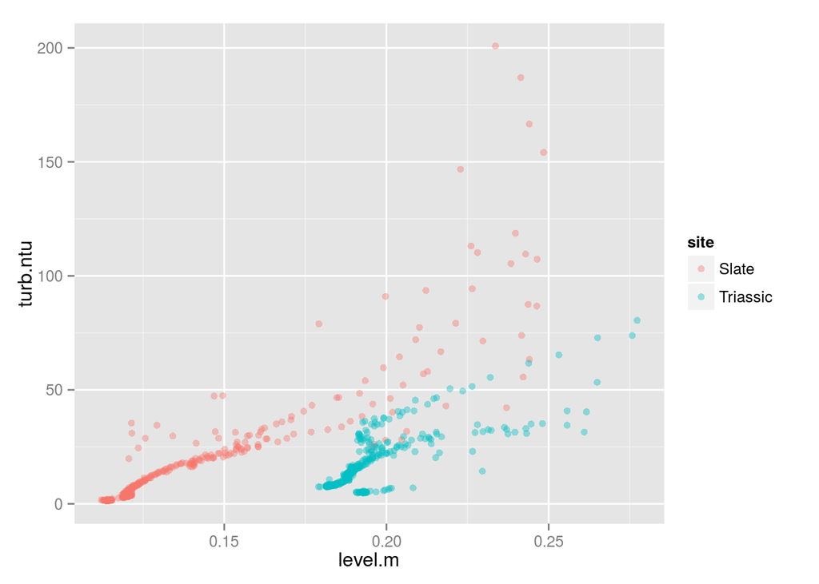

```r
#Lubridate allows you to make intervals. We can do so with this storm.
storm1 <- interval(mdy_hm('1/15/2016 10:00 AM',tz=mytz),
                    mdy_hm('1/16/2016 7:30 PM',tz=mytz))

#And then we can intuitively subset the data by using the %within% command.

sub.dat <- wide.dat[wide.dat$min5 %within% storm1,]

full.g <- ggplot(sub.dat, aes(level.m,turb.ntu,color=site))
full.g + geom_point(alpha=.4)
```

You could do a lot more with this approach including identifying a bunch of individual storms and seeing how they change over time.